# Analyzing the United States’ Incarcerated Adult Population

#### 2. Which U.S. region has the highest incarceration rates?

Based on the maps generated by the code below, it looks like Southern region of the United States generally has the highest incarceration rates.

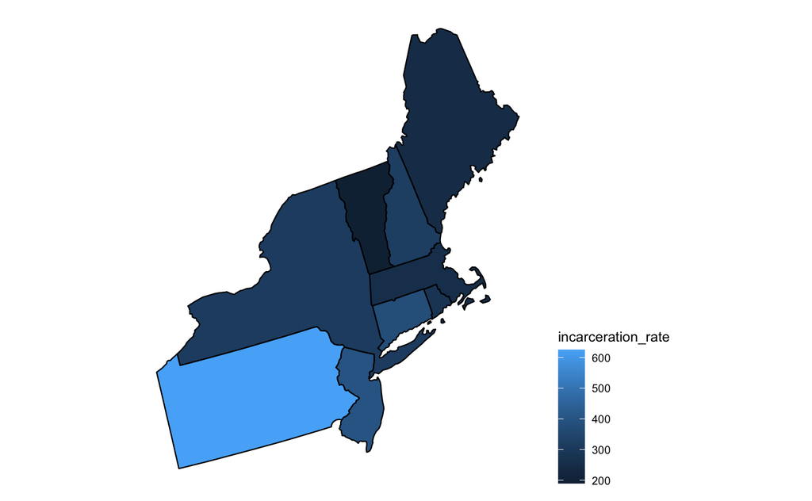

```r
# Northeast

plot_usmap(include = .northeast_region, data = incarceration_rates, values = "incarceration_rate", color = "black") + theme(legend.position = "right")
```

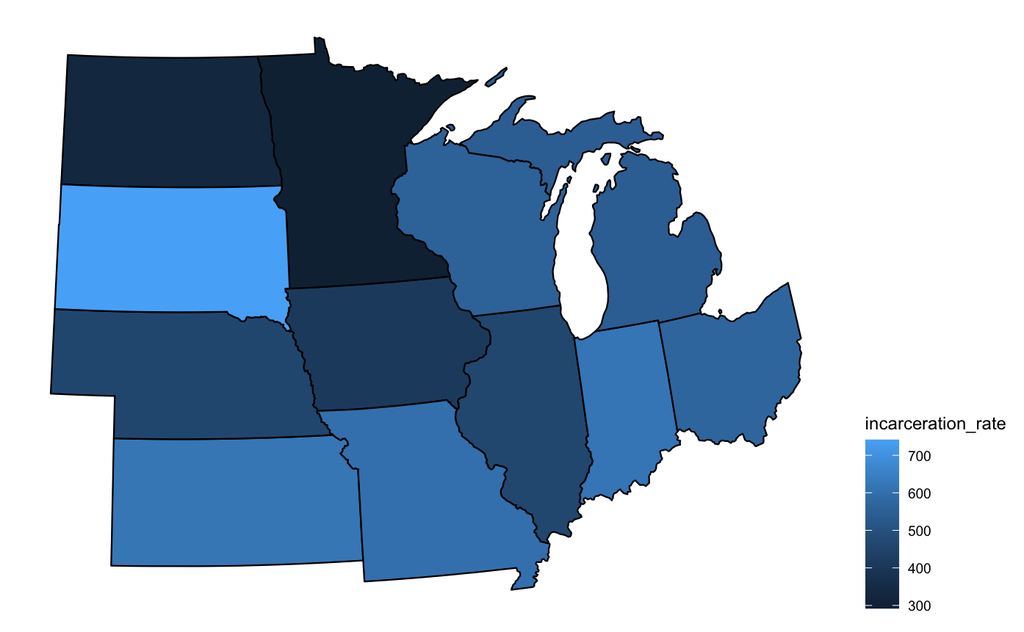

```r
# Midwest

plot_usmap(include = .midwest_region, data = incarceration_rates, values = "incarceration_rate", color = "black") + theme(legend.position = "right")
```

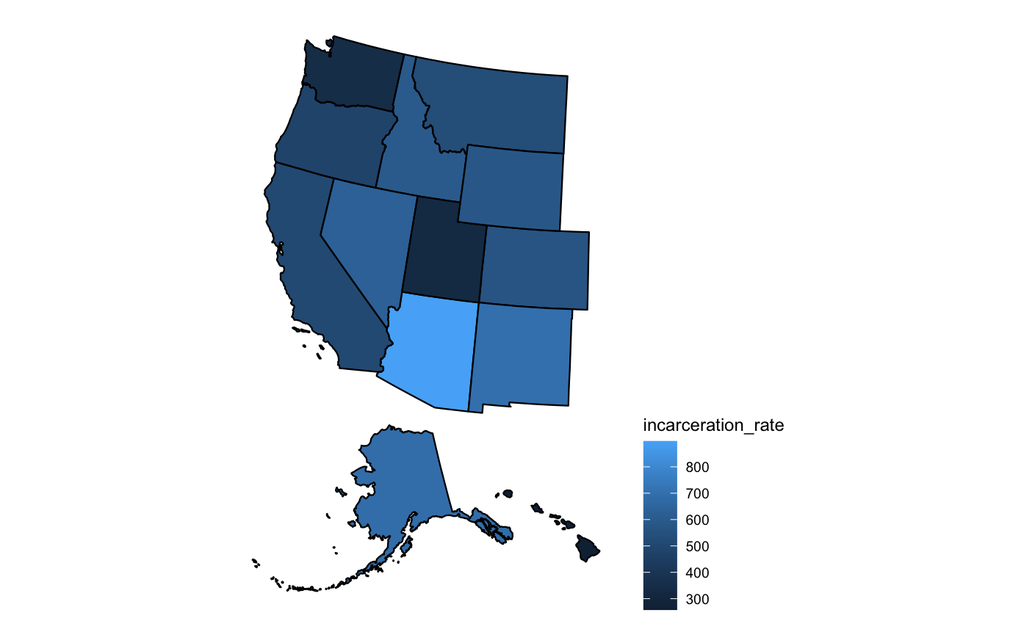

```r
# West

plot_usmap(include = .west_region, data = incarceration_rates, values = "incarceration_rate", color = "black") + theme(legend.position = "right")
```

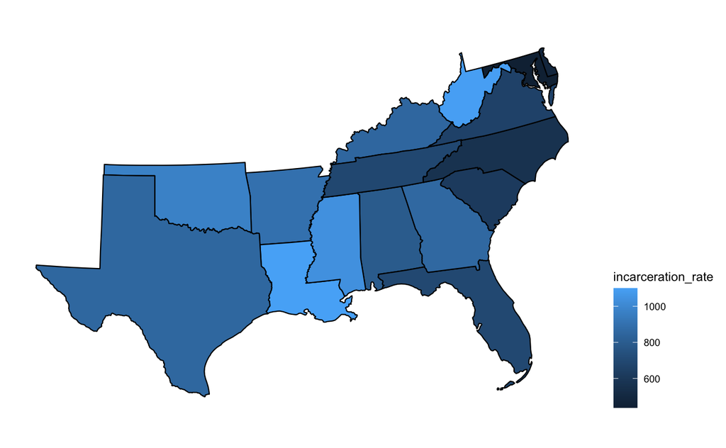

```r
# South

plot_usmap(include = .south_region, data = incarceration_rates, values = "incarceration_rate", color = "black") + theme(legend.position = "right")
```

#### 3. Which were the top 10 U.S. counties that saw the largest percent increase in prison population since 2010? Alternatively, which were the top 10 U.S. counties that saw either a decrease or no change in prison population since 2010?

```r
# net change (direct subtraction over years)

percent_counties_00 <- incarcerated_pop %>%
  select(fips, percent_incarcerated_00)

percent_counties_10 <- incarcerated_pop %>%
  select(fips, percent_incarcerated_10)

percent_counties_20 <- incarcerated_pop %>%
  select(fips, percent_incarcerated_20)

# 2000

incarcerated_pop %>%
  arrange(desc(percent_incarcerated_00)) %>%
  select(state, county, percent_incarcerated_00) %>%
  head(10)

# county level map
plot_usmap(regions = "counties", data = percent_counties_00, values = "percent_incarcerated_00", color = "black") +
  labs(title = "Title",
       subtitle = "Subtitle") +
  scale_fill_continuous(low = "#c9d9c9", high = "#236d32", name = "Legend", label = scales::comma) +
  theme(legend.position = "right")

# 2010

incarcerated_pop %>%
  arrange(desc(percent_incarcerated_10)) %>%
  select(state, county, percent_incarcerated_10) %>%
  head(10)

# county level map
plot_usmap(regions = "counties", data = percent_counties_10, values = "percent_incarcerated_10", color = "black") +
  labs(title = "Title",
       subtitle = "Subtitle") +
  scale_fill_continuous(low = "#c9d9c9", high = "#236d32", name = "Legend", label = scales::comma) +
  theme(legend.position = "right")


# 2020

incarcerated_pop %>%
  arrange(desc(percent_incarcerated_20)) %>%
  select(state, county, percent_incarcerated_20) %>%
  head(10)

# county level map
plot_usmap(regions = "counties", data = percent_counties_20, values = "percent_incarcerated_20", color = "black") +
  labs(title = "Title",
       subtitle = "Subtitle") +
  scale_fill_continuous(low = "#c9d9c9", high = "#236d32", name = "Legend", label = scales::comma) +
  theme(legend.position = "right")
```

[output not shown]

#### 4. For each U.S. state, roughly how much (%) of the state’s adult population was incarcerated/being held in a correctional facility in 2020? Compare it to figures from 2010 and 2000.

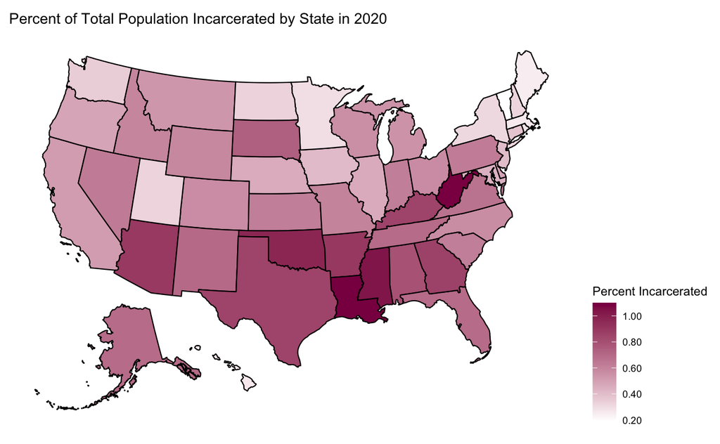

```r
# 2020

plot_usmap(data = incarceration_rates_pct, values = "pct_incarcerated_20", color = "black") +
  labs(title = "Percent of Total Population Incarcerated by State in 2020") +
  scale_fill_continuous(
    low = "white", high = "deep pink 4", name = "Percent Incarcerated", label = scales::comma) + theme(legend.position = "right")
```

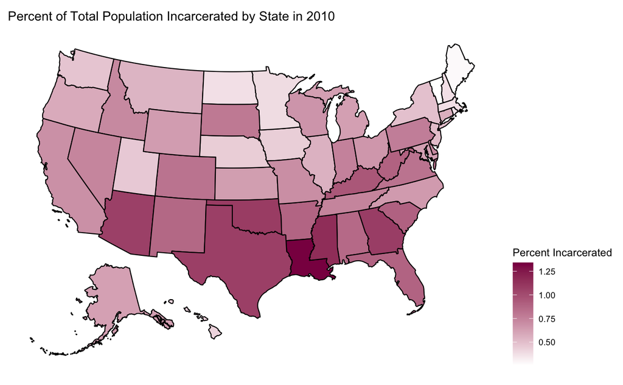

```r
# 2010

plot_usmap(data = incarceration_rates_pct, values = "pct_incarcerated_10", color = "black") +
  labs(title = "Percent of Total Population Incarcerated by State in 2010") +
  scale_fill_continuous(
    low = "white", high = "deep pink 4", name = "Percent Incarcerated", label = scales::comma) + theme(legend.position = "right")
```

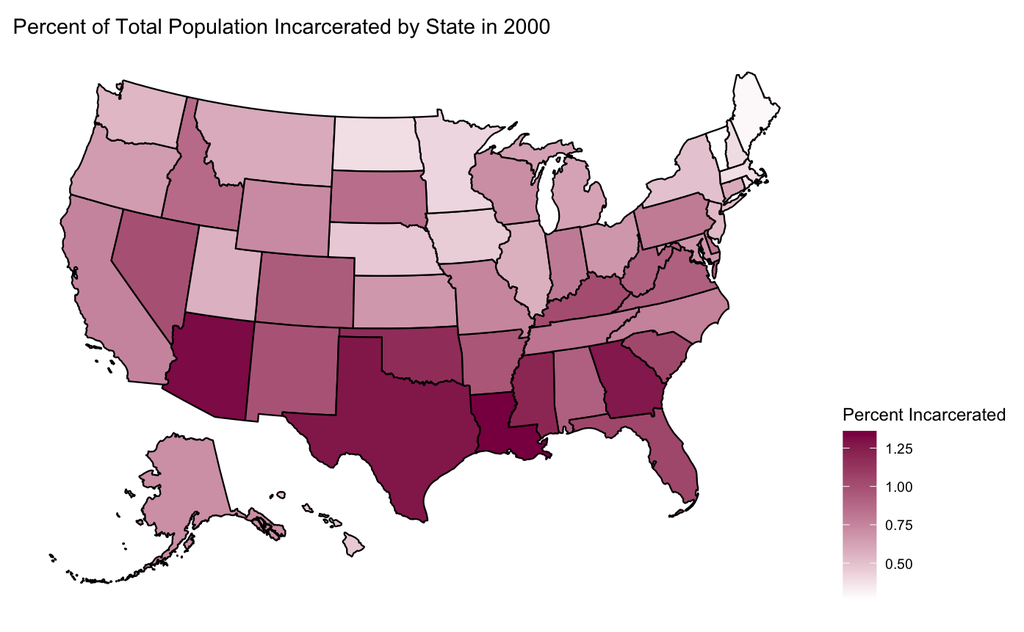

```r
# 2000

plot_usmap(data = incarceration_rates_pct, values = "pct_incarcerated_00", color = "black") +
  labs(title = "Percent of Total Population Incarcerated by State in 2000") +
  scale_fill_continuous(
    low = "white", high = "deep pink 4", name = "Percent Incarcerated", label = scales::comma) + theme(legend.position = "right")
```

#### 5. Using ACS data, compare median household incomes and incarceration rates for Colorado, Pennsylvania, Mississippi, Louisiana, and Georgia.

```r
get_acs(geography = "county",
              variables = c(medincome = "B19013_001"),
              state = "CO",
              year = 2020) %>%
  arrange(estimate)
```

| GEOID | NAME | variable | estimate | moe |
| --- | --- | --- | --- | --- |
| 08021 | Conejos County, Colorado | medincome | 33611 | 3481 |
| 08009 | Baca County, Colorado | medincome | 34655 | 3457 |
| 08023 | Costilla County, Colorado | medincome | 34732 | 5824 |
| 08011 | Bent County, Colorado | medincome | 38083 | 6482 |
| 08053 | Hinsdale County, Colorado | medincome | 39038 | 13765 |
| 08061 | Kiowa County, Colorado | medincome | 39503 | 2666 |
| 08055 | Huerfano County, Colorado | medincome | 40255 | 3754 |
| 08025 | Crowley County, Colorado | medincome | 40785 | 5977 |
| 08003 | Alamosa County, Colorado | medincome | 41121 | 3437 |
| 08099 | Prowers County, Colorado | medincome | 42648 | 3123 |

[output cut: 54 more lines]